# Tervisekindlustuse makse prognoosimine

Georg Klettenberg

2026-04-24

# 1. Sissejuhatus

Projekti eesmärk on prognoosida järgmise perioodi tervisekindlustusmakset kaks kuud enne kindlustusperioodi lõppu. Kuna algandmestikus puudus ajaline mõõde, lisasin sünteetilise 12 kuu ajaloo ning arvutasin kulupõhised tunnused.

# 2. Andmestiku kirjeldus

```
## ### Andmestiku mõõtmed
```

```
## Ridade arv: 1338
```

```
## Veergude arv: 10
```

```
## ### Andmete struktuur
```

```
## 'data.frame':    1338 obs. of  10 variables:
##  $ customer_id        : int  1 2 3 4 5 6 7 8 9 10 ...
##  $ month              : int  10 10 10 10 10 10 10 10 10 10 ...
##  $ months_to_expiry   : int  2 2 2 2 2 2 2 2 2 2 ...
##  $ age                : int  19 18 28 33 32 31 46 37 37 60 ...
##  $ bmi                : num  27.9 33.8 33 22.7 28.9 ...
##  $ smoker             : chr  "yes" "no" "no" "no" ...
##  $ monthly_claims     : num  2039 135 260 1374 412 ...
##  $ claims_last_3m     : num  4704 430 808 5424 981 ...
##  $ claims_last_6m     : num  7677 872 1740 11634 1811 ...
##  $ premium_next_period: num  454 182 232 441 216 ...
```

```
##
## ### Statistiline kokkuvõte
```

```
##   customer_id         month    months_to_expiry      age             bmi
##  Min.   :   1.0   Min.   :10   Min.   :2        Min.   :18.00   Min.   :15.96
##  1st Qu.: 335.2   1st Qu.:10   1st Qu.:2        1st Qu.:27.00   1st Qu.:26.30
##  Median : 669.5   Median :10   Median :2        Median :39.00   Median :30.40
##  Mean   : 669.5   Mean   :10   Mean   :2        Mean   :39.21   Mean   :30.66
##  3rd Qu.:1003.8   3rd Qu.:10   3rd Qu.:2        3rd Qu.:51.00   3rd Qu.:34.69
##  Max.   :1338.0   Max.   :10   Max.   :2        Max.   :64.00   Max.   :53.13
##     smoker          monthly_claims    claims_last_3m    claims_last_6m
##  Length:1338        Min.   :  12.53   Min.   :  202.7   Min.   :  514.1
##  Class :character   1st Qu.: 375.64   1st Qu.: 1163.4   1st Qu.: 2317.8
##  Mode  :character   Median : 724.28   Median : 2266.2   Median : 4544.8
##                     Mean   :1117.53   Mean   : 3338.9   Mean   : 6635.2
##                     3rd Qu.:1422.21   3rd Qu.: 4200.8   3rd Qu.: 8241.7
##                     Max.   :7929.34   Max.   :18263.1   Max.   :33270.6
##  premium_next_period
##  Min.   :166.6
##  1st Qu.:250.2
##  Median :292.7
##  Mean   :354.2
##  3rd Qu.:394.0
##  Max.   :958.5
```

```
##
## ### Esimesed 6 rida
```

| customer_id | month | months_to_expiry | age | bmi | smoker | monthly_claims | claims_last_3m | claims_last_6m | premium_next_period |
| --- | --- | --- | --- | --- | --- | --- | --- | --- | --- |
| 1 | 10 | 2 | 19 | 27.90 | yes | 2039.48 | 4704.10 | 7677.17 | 454.21 |
| 2 | 10 | 2 | 18 | 33.77 | no | 134.81 | 429.70 | 871.61 | 182.26 |
| 3 | 10 | 2 | 28 | 33.00 | no | 259.67 | 808.16 | 1740.37 | 232.19 |
| 4 | 10 | 2 | 33 | 22.70 | no | 1373.69 | 5423.97 | 11634.26 | 441.09 |
| 5 | 10 | 2 | 32 | 28.88 | no | 411.54 | 980.99 | 1811.31 | 215.91 |
| 6 | 10 | 2 | 31 | 25.74 | no | 515.84 | 1343.90 | 2297.77 | 273.41 |

# 3. Uuriv andmeanalüüs

## Järgmise perioodi kindlustusmakse jaotus

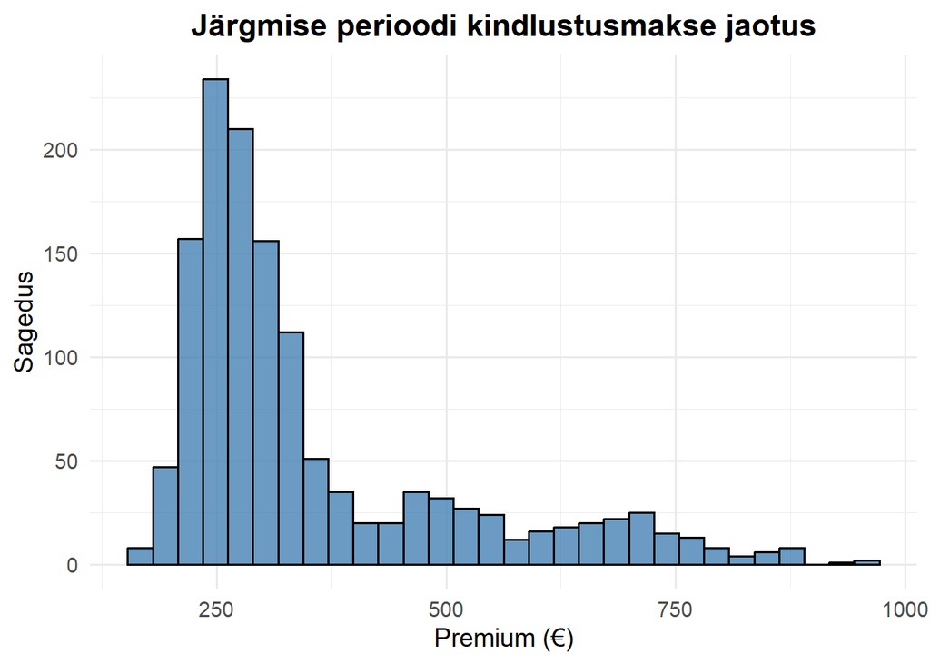

Histogramm näitab, et kindlustusmaksete jaotus on paremale kaldu. Enamik klientide makseid jääb vahemikku ligikaudu 200–350 eurot, kuid esineb ka kõrgemaid väärtusi, mis viitavad suurema riskiga klientidele.

## Suitsetaja mõju järgmise perioodi maksele

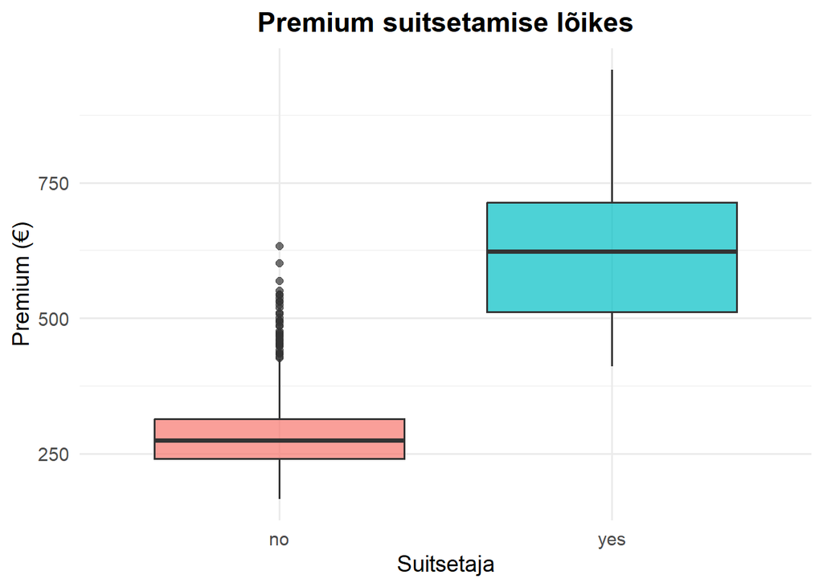

Karpdiagramm näitab selget erinevust suitsetajate ja mittesuitsetajate vahel. Suitsetajatel on oluliselt kõrgemad kindlustusmaksed ning suurem varieeruvus, mis viitab kõrgemale riskitasemele.

## Seos eelneva kuue kuu perioodi maksetega

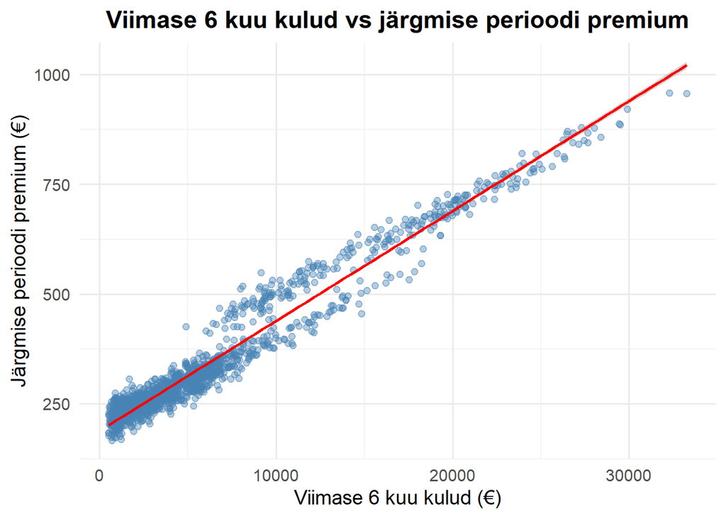

Graafik näitab tugevat positiivset seost viimase kuue kuu ravikulude ja järgmise perioodi kindlustusmakse vahel. Mida suuremad on hiljutised kulud, seda kõrgem on prognoositav premium. See on kooskõlas kindlustusloogikaga, kus kõrgem risk toob kaasa suuremad maksed. Seos on väga tugev, mis viitab sellele, et andmestik on osaliselt sünteetiline ning kulud mõjutavad premiumit otseselt.

# 4. Andmete ettevalmistus

```r
andmed$smoker <- as.factor(andmed$smoker)
```

# 5. Mudelid

## Lineaarne regressioon

```r
model <- lm(
  premium_next_period ~ age + bmi + smoker + claims_last_3m + claims_last_6m,
  data = andmed
)

summary(model)
```

```
##
## Call:
## lm(formula = premium_next_period ~ age + bmi + smoker + claims_last_3m +
##     claims_last_6m, data = andmed)
##
## Residuals:
##     Min      1Q  Median      3Q     Max
## -61.996 -13.497  -0.026  13.226  70.953
##
## Coefficients:
##                  Estimate Std. Error t value Pr(>|t|)
## (Intercept)     2.030e+02  3.269e+00  62.091   <2e-16 ***
## age            -1.710e-02  4.562e-02  -0.375    0.708
## bmi            -3.428e-02  9.516e-02  -0.360    0.719
## smokeryes       1.024e+02  2.455e+00  41.708   <2e-16 ***
## claims_last_3m  1.247e-03  9.852e-04   1.266    0.206
## claims_last_6m  1.927e-02  5.267e-04  36.579   <2e-16 ***
## ---
## Signif. codes:  0 '***' 0.001 '**' 0.01 '*' 0.05 '.' 0.1 ' ' 1
##
## Residual standard error: 20.24 on 1332 degrees of freedom
## Multiple R-squared:  0.9837, Adjusted R-squared:  0.9836
## F-statistic: 1.607e+04 on 5 and 1332 DF,  p-value: < 2.2e-16
```

Lineaarse regressioonimudeli tulemused näitavad, et kõige olulisemad tegurid järgmise perioodi kindlustusmakse kujunemisel on suitsetamine ja viimase kuue kuu ravikulud.

Suitsetajatel on keskmiselt ligikaudu 100 euro võrra kõrgem kindlustusmakse. Samuti suureneb premium proportsionaalselt viimaste kuude ravikuludega, mis on kooskõlas kindlustusloogikaga, kus suurem risk toob kaasa kõrgemad maksed.

Mudeli selgitusvõime on väga kõrge (R² ≈ 0.98), mis viitab tugevale seosele sisendtunnuste ja sihtmuutuja vahel. Samas võib nii kõrge väärtus viidata ka sellele, et andmestik on osaliselt sünteetiline.

Kuna andmestik on simuleeritud, võib seos kulude ja premiumi vahel olla tugevam kui reaalses elus.

### Ennustatud vs reaalne graafik lineaarsele regressioonile

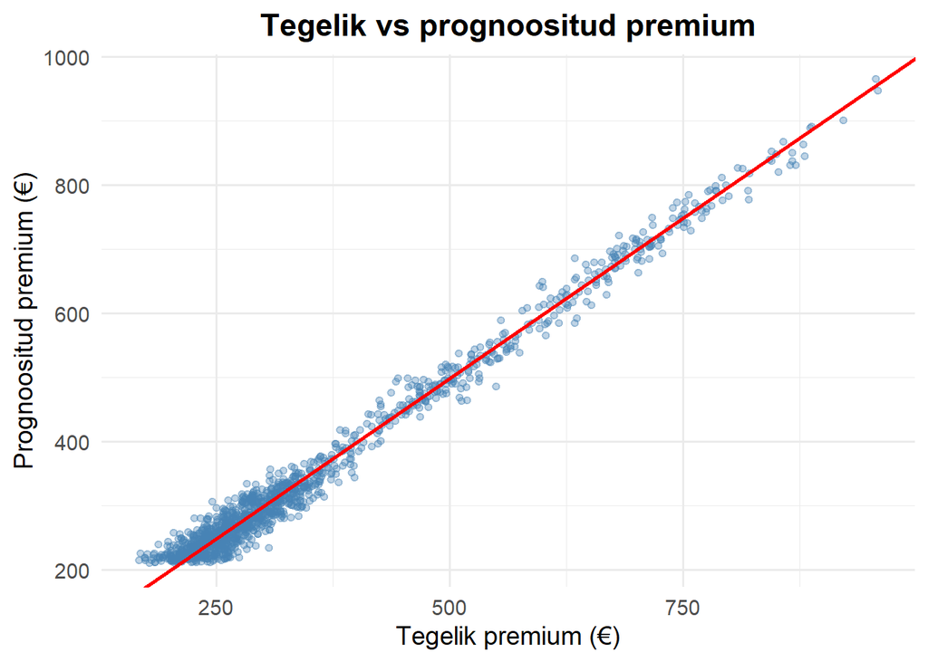

```r
# Ennustused
pred <- predict(model, andmed)

ggplot(data = andmed, aes(x = premium_next_period, y = pred)) +
  geom_point(alpha = 0.35, color = "steelblue", size = 1.5) +
  geom_abline(slope = 1, intercept = 0, color = "red", linewidth = 1) +
  labs(
    title = "Tegelik vs prognoositud premium",
    x = "Tegelik premium (€)",
    y = "Prognoositud premium (€)"
  ) +
  theme_minimal(base_size = 14) +
  theme(
    plot.title = element_text(hjust = 0.5, face = "bold")
  )
```

Graafik kujutab tegelike ja prognoositud kindlustusmaksete võrdlust. Ideaalis paikneksid kõik punktid diagonaalsel sirgel, mis tähistab täiuslikku ennustust.

Antud juhul paiknevad punktid väga tihedalt ümber diagonaali, mis viitab sellele, et mudel suudab premiumit väga täpselt prognoosida. See on kooskõlas ka kõrge R² väärtusega.

Väikesed kõrvalekalded joonest näitavad mudeli prognoosivigu, kuid üldine sobivus on väga hea.

## Random forest

```r
library(randomForest)

rf_model <- randomForest(
  premium_next_period ~ age + bmi + smoker + claims_last_6m,
  data = andmed,
  ntree = 200
)
print(rf_model)
```

```
##
## Call:
##  randomForest(formula = premium_next_period ~ age + bmi + smoker +      claims_last_6m, data = andmed, ntree = 200)
##                Type of random forest: regression
##                      Number of trees: 200
## No. of variables tried at each split: 1
##
##           Mean of squared residuals: 1069.402
##                     % Var explained: 95.72
```

Random Forest mudel suutis selgitada ligikaudu 95% andmete varieeruvusest, mis näitab head prognoosivõimet.

Võrreldes lineaarse regressioonimudeliga oli Random Forest veidi vähem täpne. See viitab sellele, et andmestikus olevad seosed on suuresti lineaarsed ning keerukam mudel ei anna antud juhul märkimisväärset eelist.

Tulemus näitab, et lihtsam lineaarne mudel võib mõnikord toimida sama hästi või isegi paremini kui keerukamad masinõppe meetodid, eriti kui andmete struktuur on lineaarne.

### Ennustatud vs reaalne graafik Random Forest mudelile

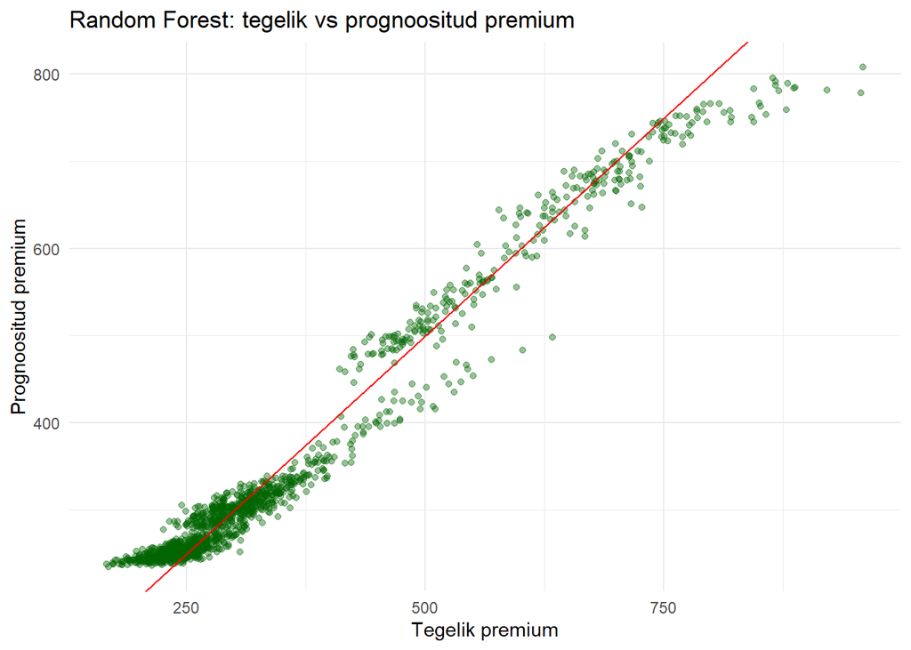

```r
rf_pred <- predict(rf_model, andmed)
ggplot(andmed, aes(x = premium_next_period, y = rf_pred)) +
  geom_point(alpha = 0.4, color = "darkgreen") +
  geom_abline(slope = 1, intercept = 0, color = "red") +
  labs(
    title = "Random Forest: tegelik vs prognoositud premium",
    x = "Tegelik premium",
    y = "Prognoositud premium"
  ) +
  theme_minimal()
```

Graafik näitab Random Forest mudeli prognooside ja tegelike väärtuste võrdlust. Punktid paiknevad küll suhteliselt lähedal diagonaalile, kuid hajuvus on suurem võrreldes lineaarse mudeliga.

Eriti on näha, et suuremate premium väärtuste korral kaldub mudel prognoose alahindama. See viitab sellele, et Random Forest mudel ei suuda antud andmestikus lineaarset seost sama täpselt tabada kui lineaarne regressioon.

Võrreldes lineaarse regressiooniga on Random Forest mudel antud juhul veidi vähem täpne. See viitab sellele, et andmestikus esinevad seosed on peamiselt lineaarsed ning keerukam mudel ei anna märkimisväärset eelist.

## Mudelite võrdlus

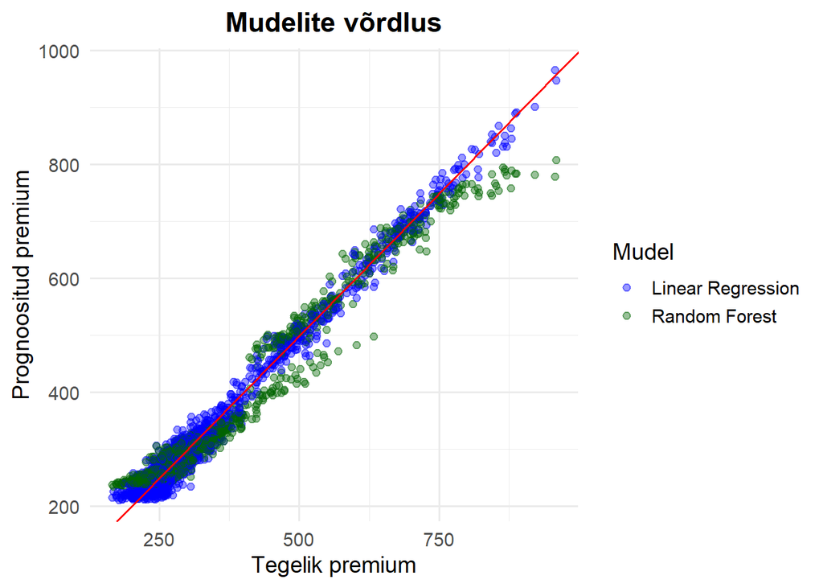

```r
library(tidyr)
library(dplyr)

plot_data <- andmed %>%
  mutate(
    LM = pred,
    RF = rf_pred
  ) %>%
  pivot_longer(cols = c(LM, RF),
               names_to = "model",
               values_to = "prediction")

ggplot(plot_data, aes(x = premium_next_period, y = prediction, color = model)) +
  geom_point(alpha = 0.4) +
  geom_abline(slope = 1, intercept = 0, color = "red") +
  scale_color_manual(
    values = c("LM" = "blue", "RF" = "darkgreen"),
    labels = c("LM" = "Linear Regression", "RF" = "Random Forest")
  ) +
  labs(
    title = "Mudelite võrdlus",
    x = "Tegelik premium",
    y = "Prognoositud premium",
    color = "Mudel"
  ) +
  theme_minimal(base_size = 14) +
  theme(
    plot.title = element_text(hjust = 0.5, face = "bold")
  )
```

Graafik võrdleb lineaarse regressiooni ja Random Forest mudeli prognoose. Mõlemad mudelid suudavad premiumit hästi ennustada, kuid lineaarne mudel paikneb lähemal ideaalsele diagonaalile, mis viitab paremale täpsusele.

# 6. Kokkuvõte

Käesoleva projekti eesmärk oli prognoosida järgmise perioodi tervisekindlustusmakset, kasutades kliendi demograafilisi tunnuseid ja varasemaid ravikulusid. Kuna algandmestik ei sisaldanud ajamõõdet, loodi sünteetiline ajajoon ning arvutati kulupõhised tunnused, nagu viimase kolme ja kuue kuu kulud.

Uuriv andmeanalüüs näitas, et kindlustusmaksete jaotus on paremale kaldu ning kõrgema riskiga klientidel esineb märkimisväärselt suuremaid makseid. Samuti ilmnes tugev positiivne seos viimaste ravikulude ja järgmise perioodi premiumi vahel.

Mudelite võrdlemisel selgus, et lineaarne regressioonimudel saavutas väga kõrge selgitusvõime (R² ≈ 0.98) ning suutis premiumit täpselt prognoosida. Random Forest mudel andis samuti häid tulemusi, kuid jäi täpsuselt veidi alla lineaarsele mudelile. See viitab sellele, et andmestikus esinevad seosed on valdavalt lineaarsed ning keerukamad mudelid ei pruugi alati anda paremaid tulemusi.

Tulemustest võib järeldada, et kõige olulisemad tegurid kindlustusmakse kujunemisel on kliendi suitsetamisharjumus ja hiljutised ravikulud, mis on kooskõlas kindlustusloogikaga, kus kõrgem risk tähendab kõrgemat makset.

Projekti piiranguks on asjaolu, et kasutatud andmestik on osaliselt sünteetiline, mistõttu võivad seosed olla tugevamad kui reaalses elus. Sellest hoolimata demonstreerib projekt edukalt masinõppe töövoogu, sealhulgas andmete ettevalmistust, feature engineering’ut, mudelite treenimist ning tulemuste hindamist.